# Lab 3 - ggplot2

Data Visualization

# 1 ggplot2

**ggplot2** package in R Programming Language also termed as Grammar of Graphics is a free, open-source, and easy-to-use visualization package widely used in R. It is the most powerful visualization package written by Hadley Wickham.

It includes several layers on which it is governed. The layers are as follows:

**Building Blocks of layers with the grammar of graphics**

$\bullet$ Data: The element is the data set itself

$\bullet$ Aesthetics: The data is to map onto the Aesthetics attributes such as x-axis, y-axis, color, fill, size, labels, alpha, shape, line width, line type

$\bullet$ Geometrics: How our data being displayed using point, line, histogram, bar, boxplot

$\bullet$ Facets: It displays the subset of the data using Columns and rows

$\bullet$ Statistics: Binning, smoothing, descriptive, intermediate

$\bullet$ Coordinates: the space between data and display using Cartesian, fixed, polar, limits

$\bullet$ Themes: Non-data link

## 1.1 Dataset we will use

`mtcars`(motor trend car road test) comprise fuel consumption and 10 aspects of automobile design and performance for 32 automobiles and come pre-installed with dplyr package in R.

```r
# Installing the package
# install.packages("dplyr")

# Loading package
library(dplyr)

# Summary of dataset in package
summary(mtcars)
```

```
##       mpg             cyl             disp             hp
##  Min.   :10.40   Min.   :4.000   Min.   : 71.1   Min.   : 52.0
##  1st Qu.:15.43   1st Qu.:4.000   1st Qu.:120.8   1st Qu.: 96.5
##  Median :19.20   Median :6.000   Median :196.3   Median :123.0
##  Mean   :20.09   Mean   :6.188   Mean   :230.7   Mean   :146.7
##  3rd Qu.:22.80   3rd Qu.:8.000   3rd Qu.:326.0   3rd Qu.:180.0
##  Max.   :33.90   Max.   :8.000   Max.   :472.0   Max.   :335.0
##       drat             wt             qsec             vs
##  Min.   :2.760   Min.   :1.513   Min.   :14.50   Min.   :0.0000
##  1st Qu.:3.080   1st Qu.:2.581   1st Qu.:16.89   1st Qu.:0.0000
##  Median :3.695   Median :3.325   Median :17.71   Median :0.0000
##  Mean   :3.597   Mean   :3.217   Mean   :17.85   Mean   :0.4375
##  3rd Qu.:3.920   3rd Qu.:3.610   3rd Qu.:18.90   3rd Qu.:1.0000
##  Max.   :4.930   Max.   :5.424   Max.   :22.90   Max.   :1.0000
##        am              gear            carb
##  Min.   :0.0000   Min.   :3.000   Min.   :1.000
##  1st Qu.:0.0000   1st Qu.:3.000   1st Qu.:2.000
##  Median :0.0000   Median :4.000   Median :2.000
##  Mean   :0.4062   Mean   :3.688   Mean   :2.812
##  3rd Qu.:1.0000   3rd Qu.:4.000   3rd Qu.:4.000
##  Max.   :1.0000   Max.   :5.000   Max.   :8.000
```

## 1.2 Example of ggplot2 package

We devise visualizations on mtcars dataset which includes 32 car brands and 11 attributes using ggplot2 layers.

### 1.2.1 Data layer:

In the data Layer we define the source of the information to be visualize, let’s use the mtcars dataset in the ggplot2 package.

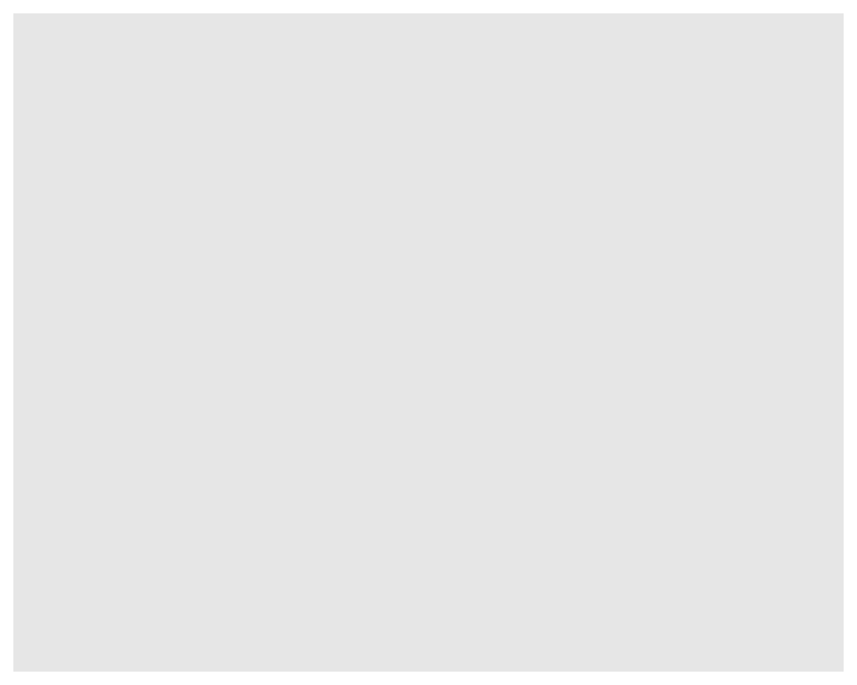

```r
# Installing the package
# install.packages("ggplot2")

# Loading packages
library(ggplot2)
library(dplyr)

# Data Layer
ggplot(data = mtcars)
```

### 1.2.2 Aesthetic Layer:

Here we will display and map dataset into certain aesthetics. The mapping of the variables to visual properties of the graph. The mappings are placed within the `aes` function (where aes stands for aesthetics).

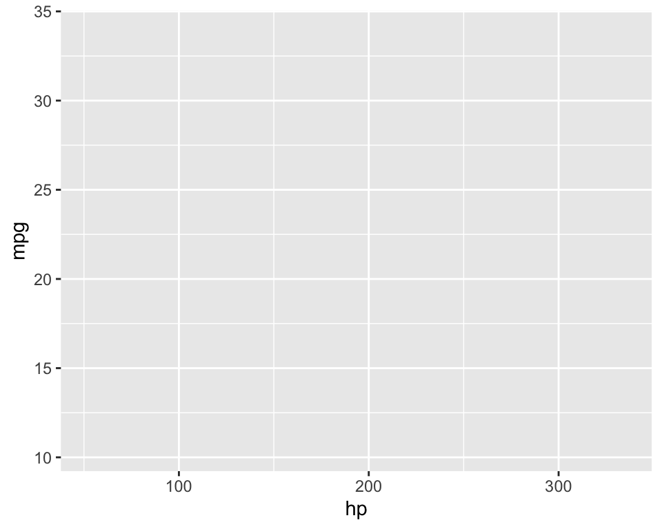

```r
# Aesthetic Layer
ggplot(data = mtcars,
       mapping = aes(x = hp, y = mpg))
```

### 1.2.3 Geometric layer:

In geometric layer control the essential elements, see how our data being displayed using point, line, histogram, bar, boxplot or others.

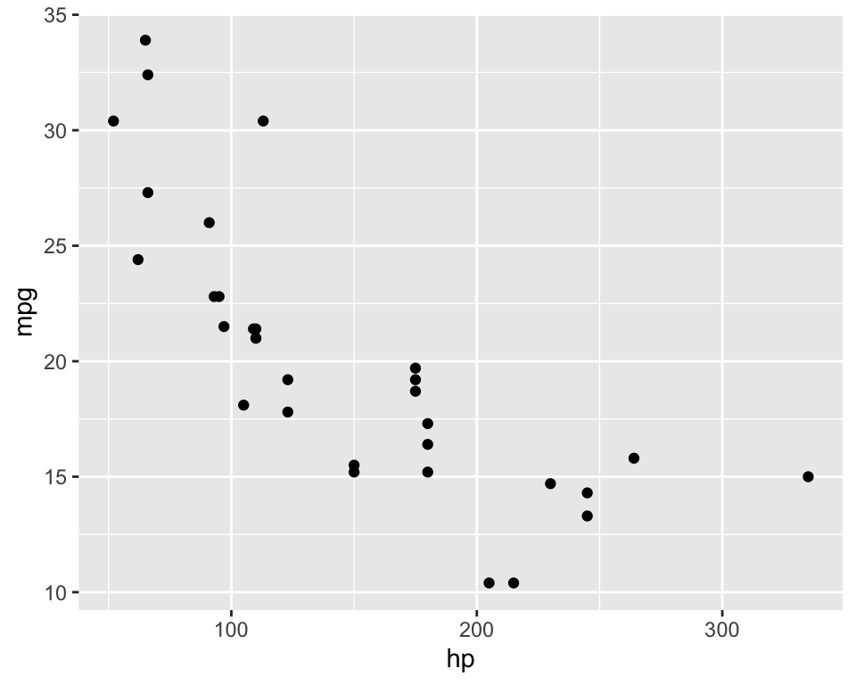

```r
# Geometric layer
# Scatterplot: two variables
ggplot(data = mtcars,
       mapping = aes(x = hp, y = mpg)) +
  geom_point()
```

A number of parameters (options) can be specified in a geom_ function. Options for the geom_point function include `color`, `size`, and `alpha`. These control the point color, size, and transparency, respectively. Transparency ranges from 0 (completely transparent) to 1 (completely opaque). Adding a degree of transparency can help visualize overlapping points.

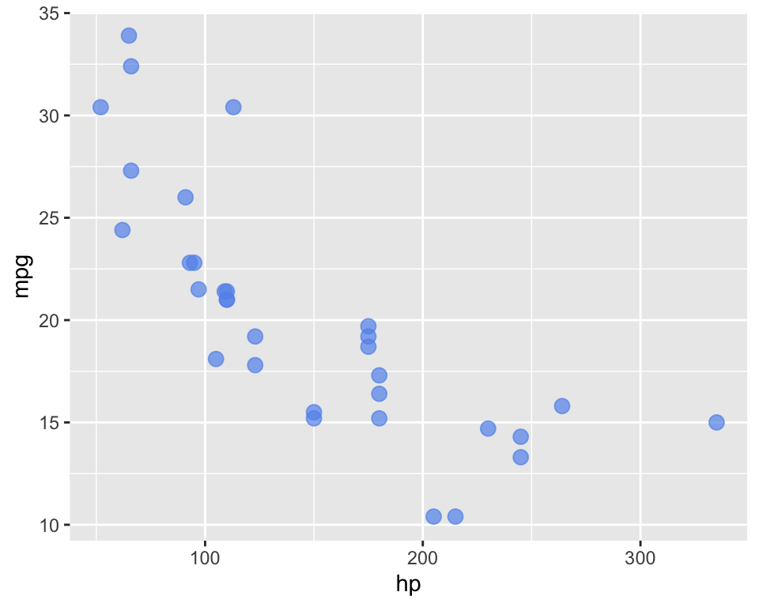

```r
# make points blue, larger, and semi-transparent
ggplot(data = mtcars,
       mapping = aes(x = hp, y = mpg)) +
  geom_point(color = "cornflowerblue",
             alpha = .7,
             size = 3)
```

Use **scatterplot** to plot **three** variables:

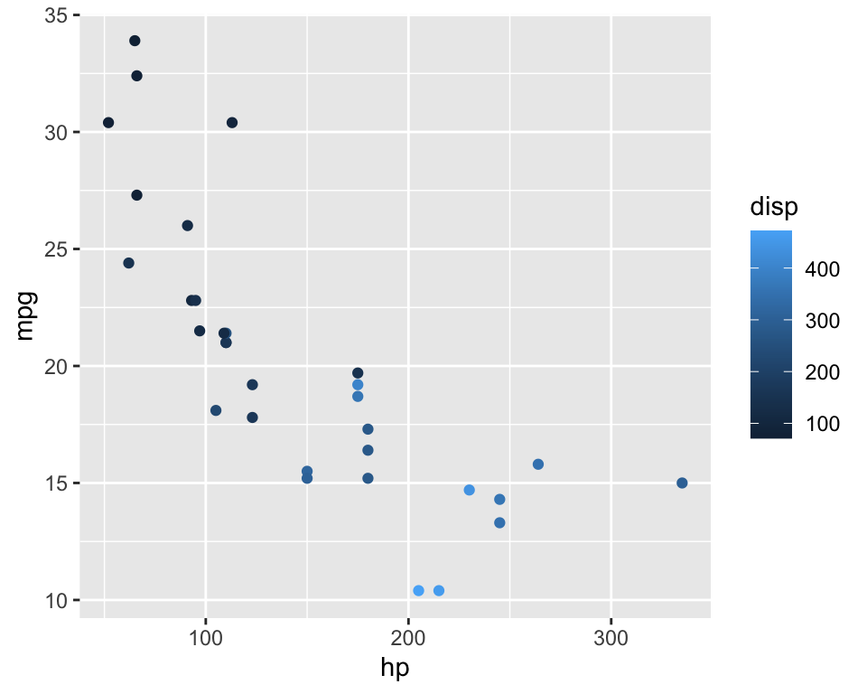

```r
# Scatterplot: three variables
ggplot(data = mtcars,
       mapping = aes(x = hp, y = mpg, col = disp)) +
  geom_point()
```

**Geometric layer**: Adding **size**, **color**, and **shape** and then plotting histogram plot.

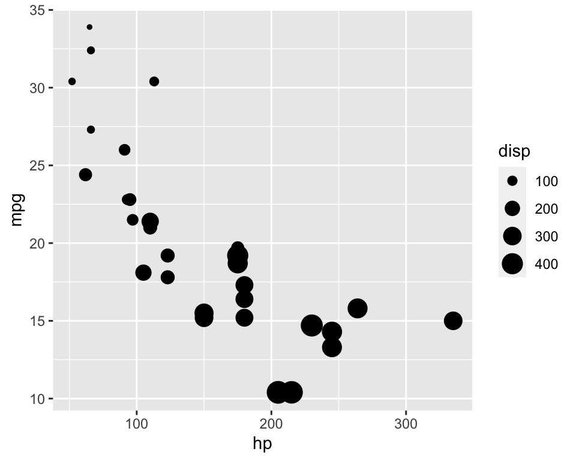

```r
# Adding size
ggplot(data = mtcars,
       mapping = aes(x = hp, y = mpg, size = disp)) +
  geom_point()
```

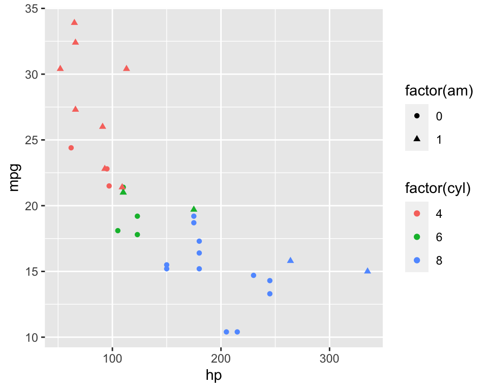

```r
# Adding color and shape
ggplot(data = mtcars,
       mapping = aes(x = hp, y = mpg, col = factor(cyl),
             shape = factor(am))) +
  geom_point()
```

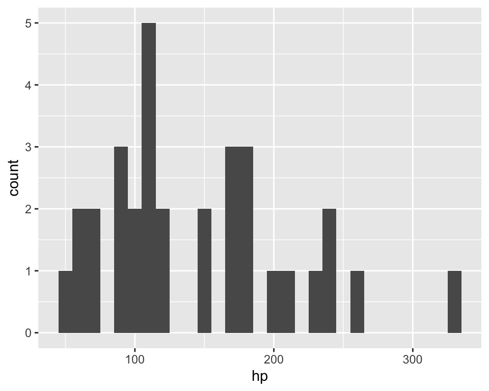

```r
# Histogram plot
ggplot(data = mtcars, aes(x = hp)) +
  geom_histogram(binwidth = 10)
```

### 1.2.4 Facet Layer:

It is used to **split** the data up into subsets of the entire dataset and it allows the subsets to be visualized on the same plot. Here we separate rows according to transmission type and separate columns according to cylinders.

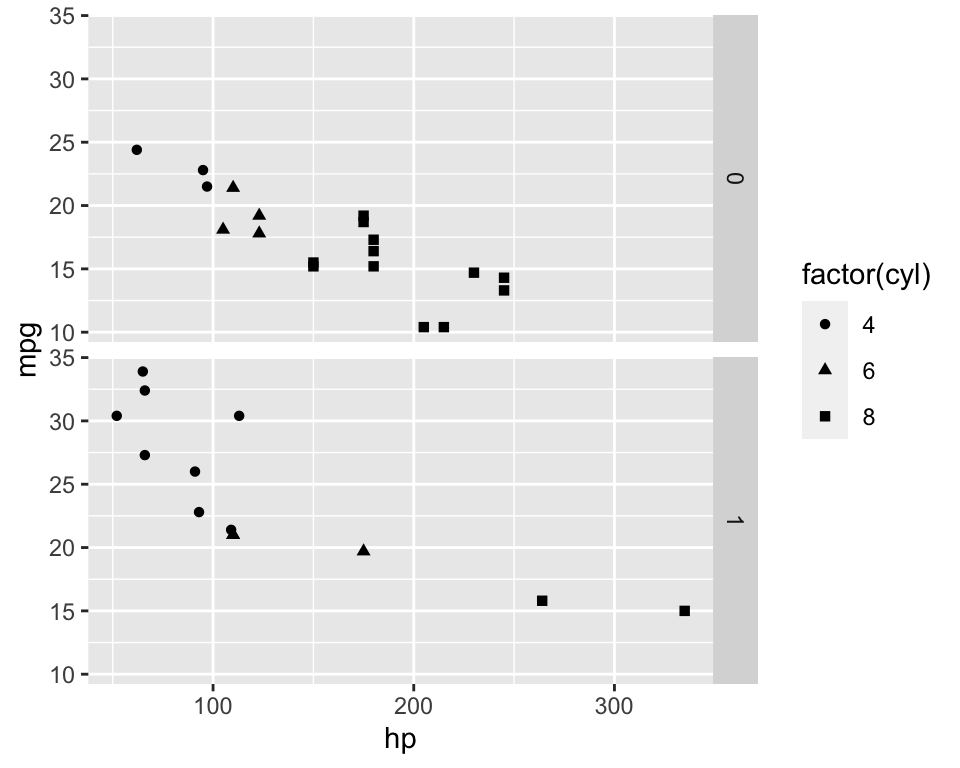

```r
# Facet Layer
p <- ggplot(data = mtcars,
            mapping = aes(x = hp, y = mpg, shape = factor(cyl))) +
  geom_point()

# Separate rows according to transmission type
# Use vars() to supply variables from the dataset
p + facet_grid(rows = vars(am))
```

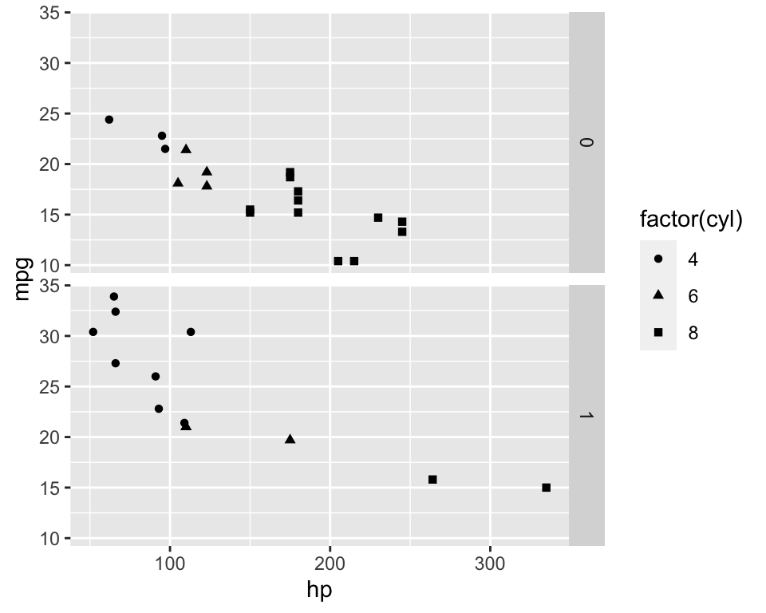

```r
# or
p + facet_grid(am ~ .)
```

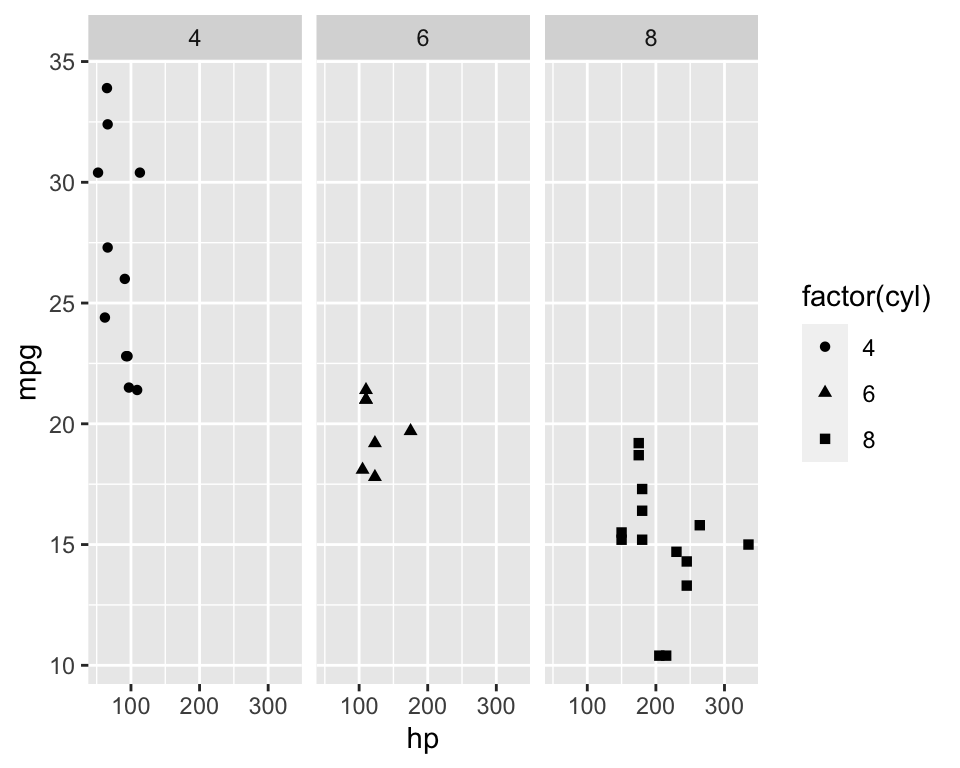

```r
# Separate columns according to cylinders
p + facet_grid(cols = vars(cyl))
```

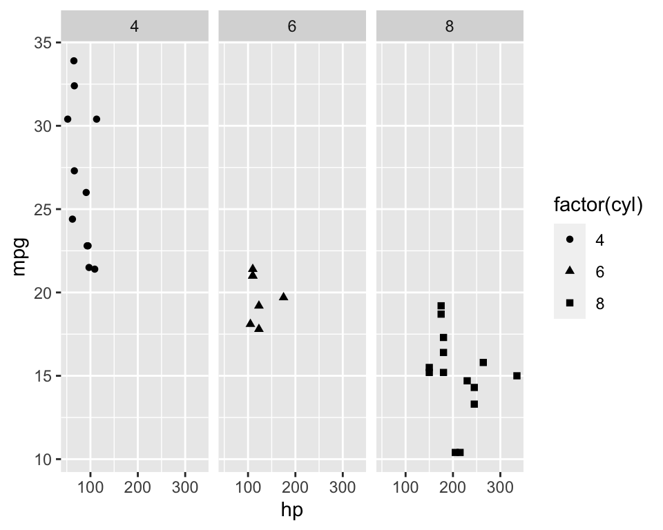

```r
#or
p + facet_grid(. ~ cyl)
```

### 1.2.5 Statistics layer

In this layer, we transform our data using binning, smoothing, descriptive, intermediate.

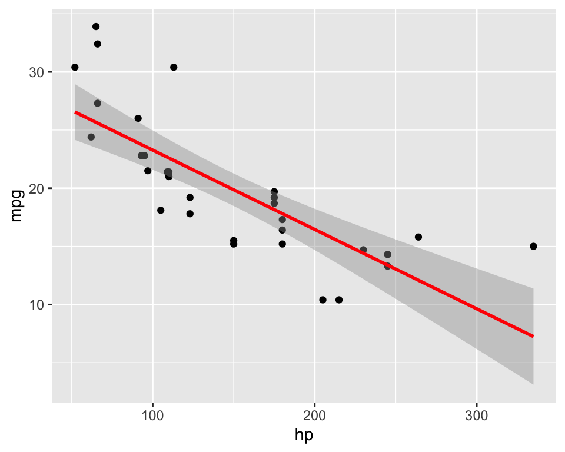

```r
# Statistics layer
ggplot(data = mtcars,
       mapping = aes(x = hp, y = mpg)) +
  geom_point() +
  stat_smooth(method = lm, col = "red", cex = 1)
```

### 1.2.6 Coordinates layer:

In these layers, data coordinates are mapped together to the mentioned plane of the graphic and we adjust the axis and changes the spacing of displayed data with control plot dimensions.

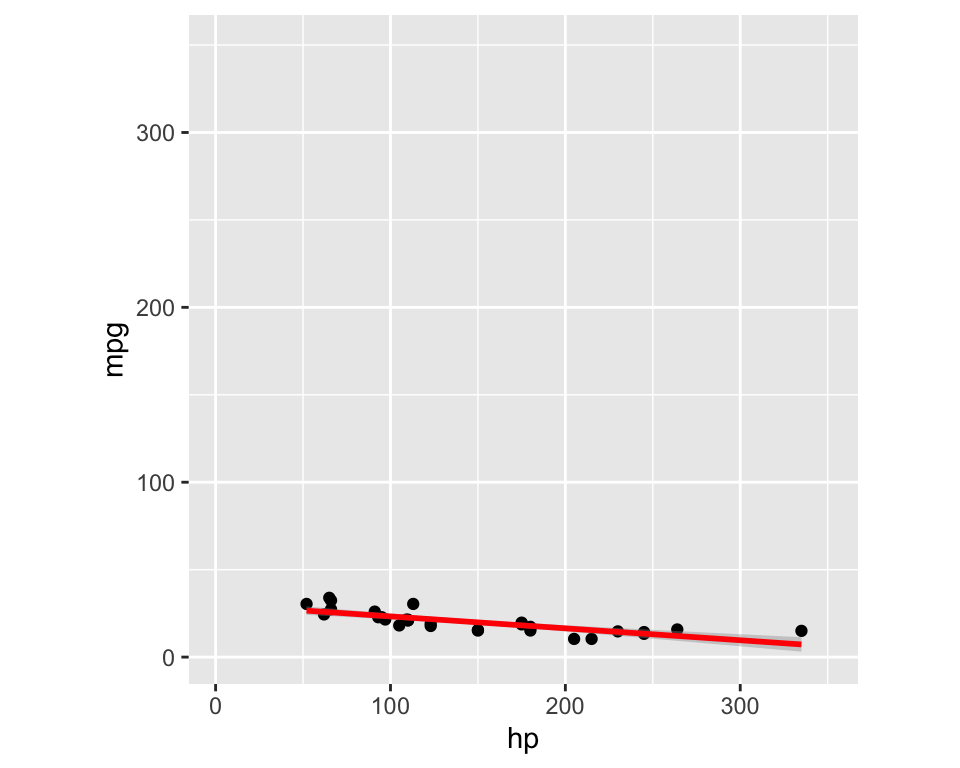

```r
# Coordinates layer: Control plot dimensions
ggplot(data = mtcars,
       mapping = aes(x = hp, y = mpg)) +
  geom_point() +
  stat_smooth(method = lm, col = "red") +
  scale_y_continuous("mpg", limits = c(2, 350)) +
  scale_x_continuous("hp", limits = c(2, 350)) +
  coord_equal()
```

`Coord_cartesian()` to proper zoom in:

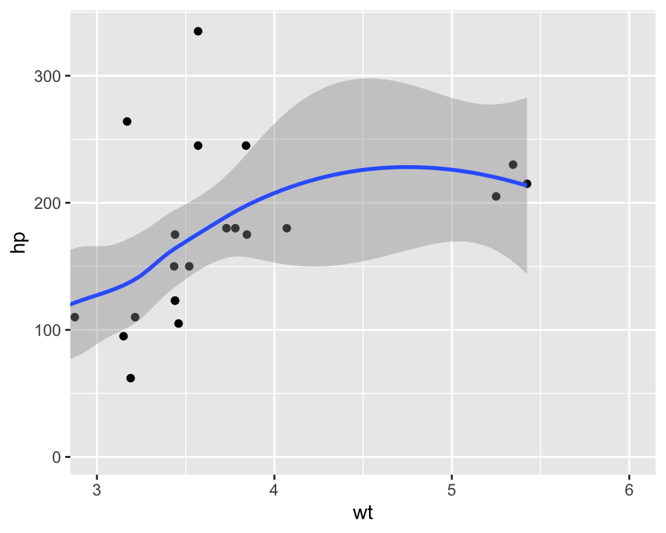

```r
# Add coord_cartesian() to proper zoom in
ggplot(data = mtcars,
       mapping = aes(x = wt, y = hp)) +
  geom_point() +
  geom_smooth(method = "loess", formula = 'y ~ x') +
  coord_cartesian(xlim = c(3, 6))
```

### 1.2.7 Theme Layer:

This layer controls the finer points of display like the font size and background color properties.

Example 1: Theme layer – `element_rect()` function

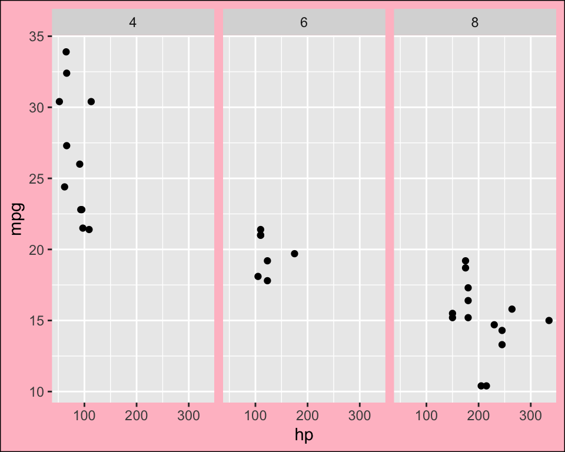

```r
# Theme layer
ggplot(data = mtcars,
       mapping = aes(x = hp, y = mpg)) +
  geom_point() +
  facet_grid(. ~ cyl) +
  theme(plot.background = element_rect(fill = "pink",
                                       colour = "black"))
```

Example 2:

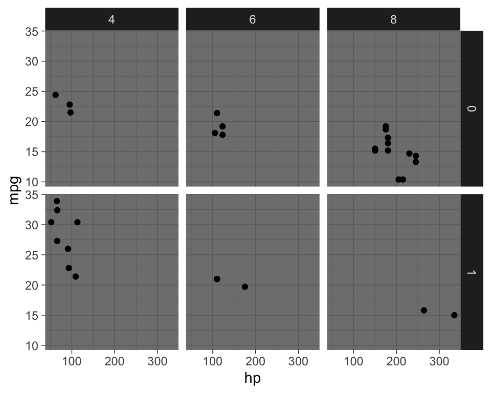

```r
# Theme layer
ggplot(data = mtcars,
       mapping = aes(x = hp, y = mpg)) +
  geom_point() +
  facet_grid(am ~ cyl) +
  theme_dark()
```

# 2 At the end

**ggplot2** provides various types of visualizations. More parameters can be used included in the package as the package gives greater control over the visualizations of data. Many packages can integrate with the ggplot2 package to make the visualizations interactive and animated.